# Cellen 2

Statistical thinking — Categorical covariates

Gavin Simpson

gavin@anivet.au.dk

Aarhus University

2025-03-10

## Introduction

We ended the last class starting to think about models with categorical predictors

We’ll recap those last few slides on ANOVA

Then look at categorical predictors more generally, including the concepts of interactions

# Analysis of Variance

## Analysis of Variance

Analysis of Variance (ANOVA) is the classic name for a Gaussian linear model where the predictor (explanatory) variables are *categorical*

Earlier ANOVA table used to partition variance in $y$ into components explained by $x_j$ & a residual component not explained by the regression model

A slightly more restricted view of ANOVA is that it is a technique for partitioning the variation in $y$ into that explained by one or more categorical predictor variables

The categories of each factor are the groups or experimental treatments

## Analysis of Variance

ANOVA considers the different sources of variation that might arise on a data set

Of particular interest is on the differences in the mean value of $y$ between groups

We can think of *within-group* and *between-group* variances

- **Between-group** variance is that due to the treatment (group) effects
- **Within-group** variance is that due to the variability of individuals & measurement error

There Will always be variation between individuals but is this within-group variance large or small, relative to the variance *between* groups?

## ANOVA how *many* ways?

One of the complications surrounding ANOVA is the convoluted nomenclature used describe variants of the method

Variants commonly distinguished by the number of categorical variables in the model

- contains a single categorical variable
- contains two categorical variables
- contains three categorical variables
- …

Two-way and higher ANOVA potentially involve the consideration of *factor—factor* interactions

## One-way ANOVA

In a we have a single categorical variable $x$ with *two or more* levels With two levels we have the same analysis as the *t* test

If we consider differences between animals of different breed, we might use an `breed` factor whose *levels* might be

- Danish Holstein,
- Red Danish
- Jersey

If we’re testing the effect of **parity**, the factor might be `parity` with levels: 1, 2, 3, & 4+

## One-way ANOVA

Assume we have a single categorical variable $x$ with three levels. The One-way ANOVA model using dummy (or indicator) coding is

$$y_i = \beta_0 + \beta_1D_{i1} + \beta_2D_{i2} + \varepsilon_i$$

Where $D_{ij}$ is the coding for the $j$th level (group) for the $i$th observation

| Group | Constant | $D_1$ | $D_2$ |
| --- | --- | --- | --- |
| 1 | 1 | 0 | 0 |
| 2 | 1 | 1 | 0 |
| 3 | 1 | 0 | 1 |

## One-way ANOVA

Measure the **between-group** variance as the *regression sums of squares*

The **within-group** variance is the *residual sums of squares*

An **omnibus test** F statistic is used to test the null hypothesis of *no differences among population group means*

$$\mathsf{H_0:} \; \beta_1 = \beta_2 = 0$$

## One-way ANOVA

Low & colleagues [(2016, *PLOS One*)](https://doi.org/10.1371/journal.pone.0154936) conducted a study to examine the effects of two different anesthetics on aspects of mouse physiology

- 12 mice anesthetised with isoflurane
- 11 mice anesthetised with alpha chloralose

Blood CO<sub>2</sub> levels were recorded after 120 minutes as the response variable

## One-way ANOVA

```r
mice <- read_csv("data/mice-anesthesia/mice-anesthesia.csv") |>
  mutate(
    anesth = fct_recode(
      anesth,
      "Isoflurane" = "iso",
      "Alpha chloralose" = "ac")) |>
  rename(anesthetic = anesth)

mice
## # A tibble: 23 × 2
##    anesthetic   co2
##    <fct>      <dbl>
##  1 Isoflurane    43
##  2 Isoflurane    35
##  3 Isoflurane    50
##  4 Isoflurane    39
##  5 Isoflurane    56
##  6 Isoflurane    54
##  7 Isoflurane    39
##  8 Isoflurane    51
##  9 Isoflurane    49
## 10 Isoflurane    54
## # ℹ 13 more rows
```

## One-way ANOVA

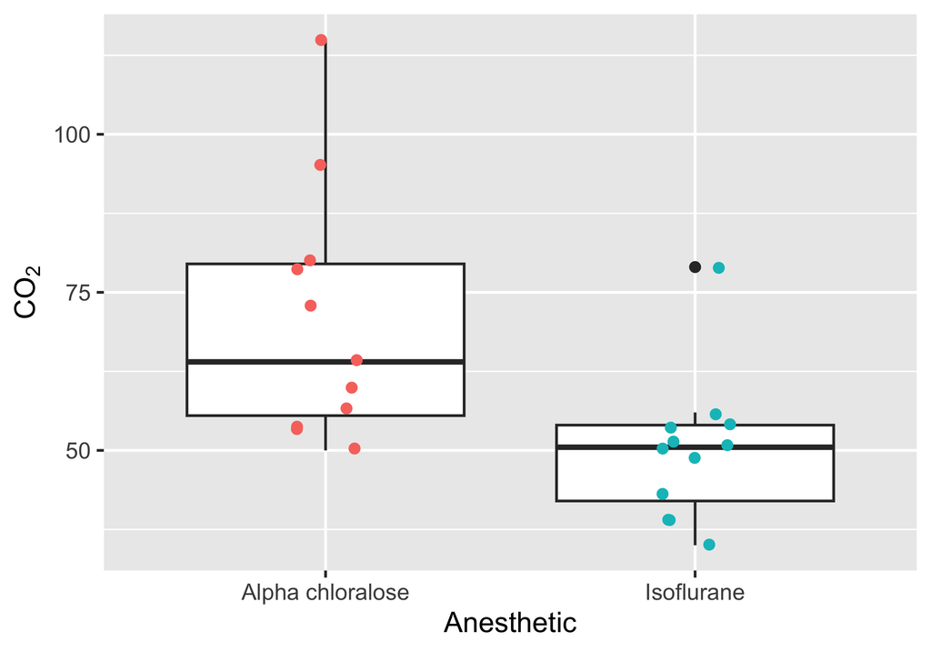

```r
mice_labs <- labs(
  x = "Anesthetic",
  y = expression(CO[2])
)
mice |>
  ggplot(aes(y = co2, x = anesthetic)) +
  geom_boxplot() +
  geom_point(
    position = position_jitter(width = 0.1),
    aes(colour = anesthetic)) +
  guides(colour = "none") +
  mice_labs
```

## One-way ANOVA

Results of fitting one-way ANOVA to the anesthesia data

```r
mice_m <- lm(co2 ~ anesthetic, data = mice)
anova(mice_m)
## Analysis of Variance Table
##
## Response: co2
##            Df Sum Sq Mean Sq F value   Pr(>F)
## anesthetic  1 2509.1 2509.09  9.5647 0.005515 **
## Residuals  21 5508.9  262.33
## ---
## Signif. codes:  0 '***' 0.001 '**' 0.01 '*' 0.05 '.' 0.1 ' ' 1
```

This is the decomposition of the variance in the data into that explained by `anesthetic` and the unexplained (residual) variance

## One-way ANOVA

This is just a Gaussian linear model

```r
summary(mice_m)
##
## Call:
## lm(formula = co2 ~ anesthetic, data = mice)
##
## Residuals:
##    Min     1Q Median     3Q    Max
## -20.91 -11.00   0.00   5.00  44.09
##
## Coefficients:
##                      Estimate Std. Error t value Pr(>|t|)
## (Intercept)            70.909      4.883  14.520 2.01e-12 ***
## anestheticIsoflurane  -20.909      6.761  -3.093  0.00552 **
## ---
## Signif. codes:  0 '***' 0.001 '**' 0.01 '*' 0.05 '.' 0.1 ' ' 1
##
## Residual standard error: 16.2 on 21 degrees of freedom
## Multiple R-squared:  0.3129, Adjusted R-squared:  0.2802
## F-statistic: 9.565 on 1 and 21 DF,  p-value: 0.005515
```

## Contrasts

With the default contrasts (treatment contrasts) and an intercept we have:

```r
coef(summary(mice_m))
##                       Estimate Std. Error  t value     Pr(>|t|)
## (Intercept)           70.90909   4.883451 14.52028 2.010337e-12
## anestheticIsoflurane -20.90909   6.760831 -3.09268 5.515219e-03
```

- `(Intercept)` — mean CO<sub>2</sub> for the reference level (`Alpha chloralose`)
- `anestheticIsoflurane` — **difference** between mean CO<sub>2</sub> for `Alpha chloralose` samples and `Isoflurane` samples

```r
mice |>
  group_by(anesthetic) |>
  summarise(mean = mean(co2))
## # A tibble: 2 × 2
##   anesthetic        mean
##   <fct>            <dbl>
## 1 Alpha chloralose  70.9
## 2 Isoflurane        50
```

## One-way ANOVA

Comparisons; this comparison coincides with a specific term in the model, so the `Estimate` is the same as from the `summary()` output earlier

```r
mice_m |>
  avg_predictions(by = "anesthetic", hypothesis = ~ pairwise,
    df = df.residual(mice_m))
##
##                         Hypothesis Estimate Std. Error     t Pr(>|t|)   S 2.5 %
##  (Isoflurane) - (Alpha chloralose)    -20.9       6.76 -3.09  0.00552 7.5   -35
##  97.5 % Df
##   -6.85 21
##
## Type:  response
```

But in general, comparing different levels against one another will involve more than reading off values from the `summary()` output

## One-way ANOVA

Consider the small milk yield data

```r
milk <- read_csv("data/itve-milk/milk-yield.csv") |>
  mutate(breed = factor(
    breed, levels = c(2,8),
      labels = c("Holsteins", "Cross-breed")),
    parity = factor(parity, levels = 1:4)) |>
  rename(
    cow_id = cowid,
    milk_jan_kg = kgmilk1,
    milk_feb_kg = kgmilk2
  )
milk
## # A tibble: 111 × 5
##    breed     parity cow_id milk_jan_kg milk_feb_kg
##    <fct>     <fct>   <dbl>       <dbl>       <dbl>
##  1 Holsteins 3         111        16          16.1
##  2 Holsteins 4         888        27.4        23
##  3 Holsteins 4         907        17.8        21.7
##  4 Holsteins 4         932        21.9        25
##  5 Holsteins 4         982        18.9        19.6
##  6 Holsteins 4        1056        18.7        21.7
##  7 Holsteins 4        1068         9.1        13.6
##  8 Holsteins 4        1089        19.7        22.4
##  9 Holsteins 4        1091        11.8        20.2
## 10 Holsteins 4        1104        29.3        34.6
## # ℹ 101 more rows
```

## Milk yield model

```r
milk_m <- lm(milk_jan_kg ~ parity, data = milk)
summary(milk_m)
##
## Call:
## lm(formula = milk_jan_kg ~ parity, data = milk)
##
## Residuals:
##      Min       1Q   Median       3Q      Max
## -17.7800  -3.1692   0.5222   3.9211  19.3091
##
## Coefficients:
##             Estimate Std. Error t value Pr(>|t|)
## (Intercept)   18.561      1.029  18.046  < 2e-16 ***
## parity2        3.417      1.424   2.400  0.01813 *
## parity3        3.319      1.674   1.983  0.04998 *
## parity4        5.230      1.626   3.216  0.00172 **
## ---
## Signif. codes:  0 '***' 0.001 '**' 0.01 '*' 0.05 '.' 0.1 ' ' 1
##
## Residual standard error: 5.908 on 107 degrees of freedom
## Multiple R-squared:  0.09834,    Adjusted R-squared:  0.07306
## F-statistic:  3.89 on 3 and 107 DF,  p-value: 0.01106
```

## Pairwise comparisons

Comparisons; here we are comparing each parity with every other parity

```r
milk_m |>
  avg_predictions(by = "parity", hypothesis = ~ pairwise)
##
##  Hypothesis Estimate Std. Error       z Pr(>|z|)   S   2.5 % 97.5 %
##   (2) - (1)   3.4172       1.42  2.3998   0.0164 5.9  0.6263   6.21
##   (3) - (1)   3.3194       1.67  1.9825   0.0474 4.4  0.0378   6.60
##   (4) - (1)   5.2303       1.63  3.2162   0.0013 9.6  2.0429   8.42
##   (3) - (2)  -0.0978       1.65 -0.0593   0.9527 0.1 -3.3274   3.13
##   (4) - (2)   1.8131       1.60  1.1340   0.2568 2.0 -1.3207   4.95
##   (4) - (3)   1.9109       1.83  1.0468   0.2952 1.8 -1.6669   5.49
##
## Type:  response
```

## Comparisons

Comparisons are differences of model predictions

Milk model is

$$\begin{align*}
\mathtt{milk\_jan\_kg}_i & \sim \text{Normal}(\mu_i, \sigma) \\
\mu_i & = \beta_0 + \beta_1 D_{1i} + \beta_2 D_{2i} + \beta_3 D_{3i}
\end{align*}$$

```r
coef(milk_m)
## (Intercept)     parity2     parity3     parity4
##   18.560606    3.417172    3.319394    5.230303
```

## Comparisons

$$\begin{align*}
\mathtt{milk\_jan\_kg}_i & \sim \text{Normal}(\mu_i, \sigma) \\
\mu_i & = \beta_0 + \beta_1 D_{1i} + \beta_2 D_{2i} + \beta_3 D_{3i}
\end{align*}$$

```r
coef(milk_m)
## (Intercept)     parity2     parity3     parity4
##   18.560606    3.417172    3.319394    5.230303
```

- $\beta_0$ is `(Intercept)`
- $\beta_1$ is `parity2`
- $\beta_2$ is `parity3`
- $\beta_3$ is `parity4`

## Comparisons

```r
coef(milk_m)
## (Intercept)     parity2     parity3     parity4
##   18.560606    3.417172    3.319394    5.230303
```

- Parity 1 $\widehat{\mathtt{milk\_jan\_kg}} = \beta_0$
- Parity 4 $\widehat{\mathtt{milk\_jan\_kg}} = \beta_0 + \beta_3$

Comparison between parties 3 and 4?

$$\begin{align*}
C_{\mathtt{3} - \mathtt{4}} & = \widehat{\mathtt{milk\_jan\_kg}}_{\mathtt{parity} = 3} - \widehat{\mathtt{milk\_jan\_kg}}_{\mathtt{parity} = 4} \\
& = (\beta_0 + \beta_2) - (\beta_0 + \beta_3) \\
& = \beta_2 - \beta_3 \\
& = 3.319394 - 5.230303 \\
& \approx -1.911
\end{align*}$$

# Interactions

## Interactions

Up to now we’ve only considered the main effects of the variables in our model

There, terms are additive, each variable contributing an amount to the model irrespective of the values of the other predictors

But what if the effect of one variable depends upon the value of one or more other variables?

This is where interaction terms come in

## Interaction terms

Two explanatory variables interact when the partial effect of one depends on the *value* of the other

Marginal effect — effect of $x_1$ on $y$ *ignoring* the effects on $y$ of the other variables $x_j$

Partial effect — effect of $x_1$ on $y$ *accounting for* the effects on $y$ of the other variables $x_j$

Interactions occur in several types

- continuous – factor interactions
- continuous – continuous interactions
- factor – factor interactions

## Continuous–factor

We’ve been plotting continuous–factor interactions quite a lot

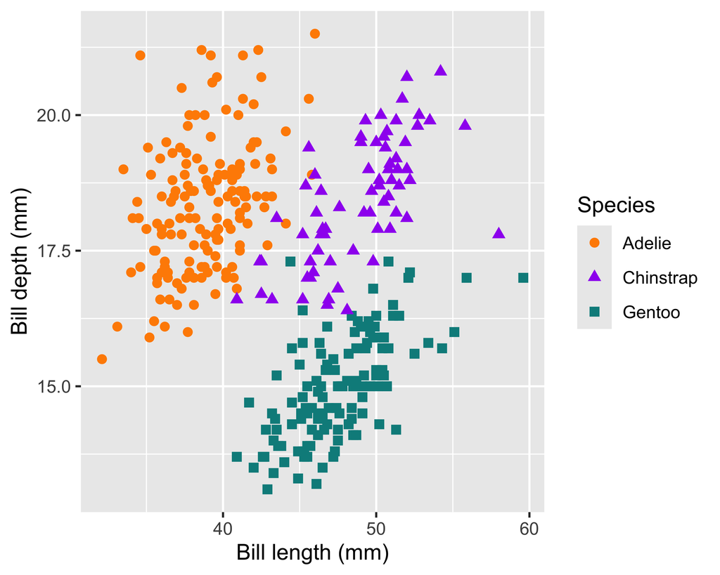


## Continuous–factor

Two models

$$\begin{align*}
\mathtt{bill\_depth\_mm}_i & \sim \text{Normal}(\mu_i, \sigma) \\
\mu_i & = \beta_0 + \textcolor{red}{\mathtt{bill\_length\_mm}_i} + \textcolor{red}{\mathtt{species}_i}
\end{align*}$$

$$\begin{align*}
\mathtt{bill\_depth\_mm}_i & \sim \text{Normal}(\mu_i, \sigma) \\
\mu_i & = \beta_0 + \textcolor{red}{\mathtt{bill\_length\_mm}_i} + \textcolor{red}{\mathtt{species}_i} \\
& + \textcolor{blue}{\mathtt{bill\_length\_mm}_i \times \mathtt{species}_i}
\end{align*}$$

Red: *main effects* Blue: *interaction*

```r
# just the main effects
bill_m1 <- lm(bill_depth_mm ~ bill_length_mm + species, data = penguins)

# main effects *and* interaction
bill_m2 <- lm(bill_depth_mm ~ bill_length_mm * species, data = penguins)
```

## Continuous–factor

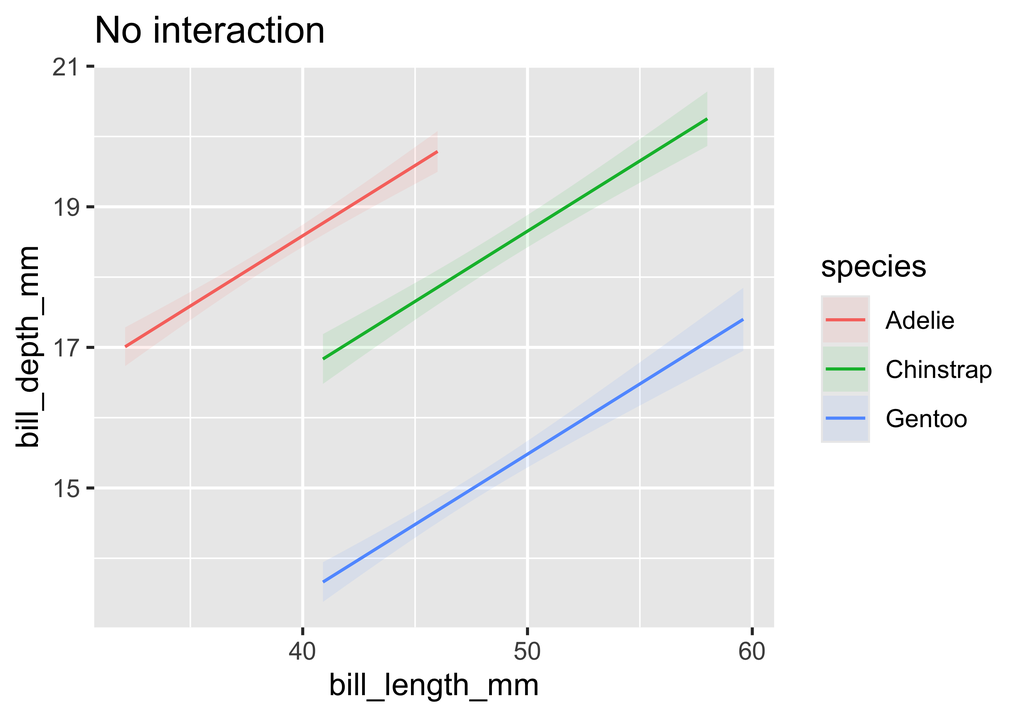

```r
bill_m1 |>
  plot_predictions(
    by = c("bill_length_mm", "species")) +
  labs(title = "No interaction")
```

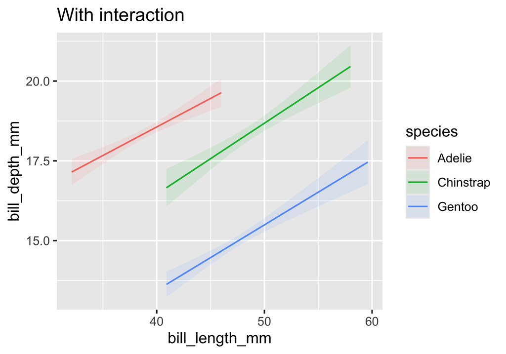

```r
bill_m2 |>
  plot_predictions(
    by = c("bill_length_mm", "species")) +
  labs(title = "With interaction")
```

Little difference because the estimated values for the interaction terms are **small**

## Continuous–factor

Little visible difference because the estimated values for the interaction terms are **small**

```r
printCoefmat(coef(summary(bill_m2)))
##                                  Estimate Std. Error t value  Pr(>|t|)
## (Intercept)                     11.409124   1.138121 10.0245 < 2.2e-16 ***
## bill_length_mm                   0.178834   0.029271  6.1096 2.764e-09 ***
## speciesChinstrap                -3.839984   2.053982 -1.8695 0.0624185 .
## speciesGentoo                   -6.158116   1.754505 -3.5099 0.0005094 ***
## bill_length_mm:speciesChinstrap  0.043377   0.045575  0.9518 0.3418952
## bill_length_mm:speciesGentoo     0.026010   0.040541  0.6416 0.5215897
## ---
## Signif. codes:  0 '***' 0.001 '**' 0.01 '*' 0.05 '.' 0.1 ' ' 1
```

## Continuous–factor

Interactions between factors can be represented as dummy variables, indicating group/combination membership

Reference level (`Adelie`) absorbed into the intercept term

Model is parameterised in terms of differences of means from the reference level

```r
head(model.matrix(bill_m1), n = 3)
##   (Intercept) bill_length_mm speciesChinstrap speciesGentoo
## 1           1           39.1                0             0
## 2           1           39.5                0             0
## 3           1           40.3                0             0
tail(model.matrix(bill_m2), n = 3)
##     (Intercept) bill_length_mm speciesChinstrap speciesGentoo
## 342           1           49.6                1             0
## 343           1           50.8                1             0
## 344           1           50.2                1             0
##     bill_length_mm:speciesChinstrap bill_length_mm:speciesGentoo
## 342                            49.6                            0
## 343                            50.8                            0
## 344                            50.2                            0
```

## Continuous–factor

Usual parameterisation: `bill_depth_mm ~ bill_length_mm * species`

Alternative parameterisation: `bill_depth_mm ~ species / bill_length_mm`

```r
# Alternate parameterisation
bill_m3 <- lm(bill_depth_mm ~ species / bill_length_mm, data = penguins)

# Alternate parametrisation plus dropping of intercept
bill_m4 <- lm(bill_depth_mm ~ species / bill_length_mm - 1, data = penguins)
```

## Continuous–factor

```r
# Alternate parameterisation
bill_m3 |> tidy()
## # A tibble: 6 × 5
##   term                            estimate std.error statistic  p.value
##   <chr>                              <dbl>     <dbl>     <dbl>    <dbl>
## 1 (Intercept)                       11.4      1.14       10.0  7.28e-21
## 2 speciesChinstrap                  -3.84     2.05       -1.87 6.24e- 2
## 3 speciesGentoo                     -6.16     1.75       -3.51 5.09e- 4
## 4 speciesAdelie:bill_length_mm       0.179    0.0293      6.11 2.76e- 9
## 5 speciesChinstrap:bill_length_mm    0.222    0.0349      6.36 6.55e-10
## 6 speciesGentoo:bill_length_mm       0.205    0.0280      7.30 2.06e-12
```

## Continuous–factor

```r
# Alternate parametrisation plus dropping of intercept
bill_m4 |> tidy()
## # A tibble: 6 × 5
##   term                            estimate std.error statistic  p.value
##   <chr>                              <dbl>     <dbl>     <dbl>    <dbl>
## 1 speciesAdelie                     11.4      1.14       10.0  7.28e-21
## 2 speciesChinstrap                   7.57     1.71        4.43 1.29e- 5
## 3 speciesGentoo                      5.25     1.34        3.93 1.02e- 4
## 4 speciesAdelie:bill_length_mm       0.179    0.0293      6.11 2.76e- 9
## 5 speciesChinstrap:bill_length_mm    0.222    0.0349      6.36 6.55e-10
## 6 speciesGentoo:bill_length_mm       0.205    0.0280      7.30 2.06e-12
```

## Interaction?

```r
summary(bill_m4)
##
## Call:
## lm(formula = bill_depth_mm ~ species/bill_length_mm - 1, data = penguins)
##
## Residuals:
##     Min      1Q  Median      3Q     Max
## -2.6574 -0.6675 -0.0524  0.5383  3.5032
##
## Coefficients:
##                                 Estimate Std. Error t value Pr(>|t|)
## speciesAdelie                   11.40912    1.13812  10.025  < 2e-16 ***
## speciesChinstrap                 7.56914    1.70983   4.427 1.29e-05 ***
## speciesGentoo                    5.25101    1.33528   3.933 0.000102 ***
## speciesAdelie:bill_length_mm     0.17883    0.02927   6.110 2.76e-09 ***
## speciesChinstrap:bill_length_mm  0.22221    0.03493   6.361 6.55e-10 ***
## speciesGentoo:bill_length_mm     0.20484    0.02805   7.303 2.06e-12 ***
## ---
## Signif. codes:  0 '***' 0.001 '**' 0.01 '*' 0.05 '.' 0.1 ' ' 1
##
## Residual standard error: 0.9548 on 336 degrees of freedom
##   (2 observations deleted due to missingness)
## Multiple R-squared:  0.997,  Adjusted R-squared:  0.9969
## F-statistic: 1.858e+04 on 6 and 336 DF,  p-value: < 2.2e-16
anova(bill_m1, bill_m2)
## Analysis of Variance Table
##
## Model 1: bill_depth_mm ~ bill_length_mm + species
## Model 2: bill_depth_mm ~ bill_length_mm * species
##   Res.Df    RSS Df Sum of Sq      F Pr(>F)
## 1    338 307.20
## 2    336 306.32  2   0.87243 0.4785 0.6202
```

## Interaction?

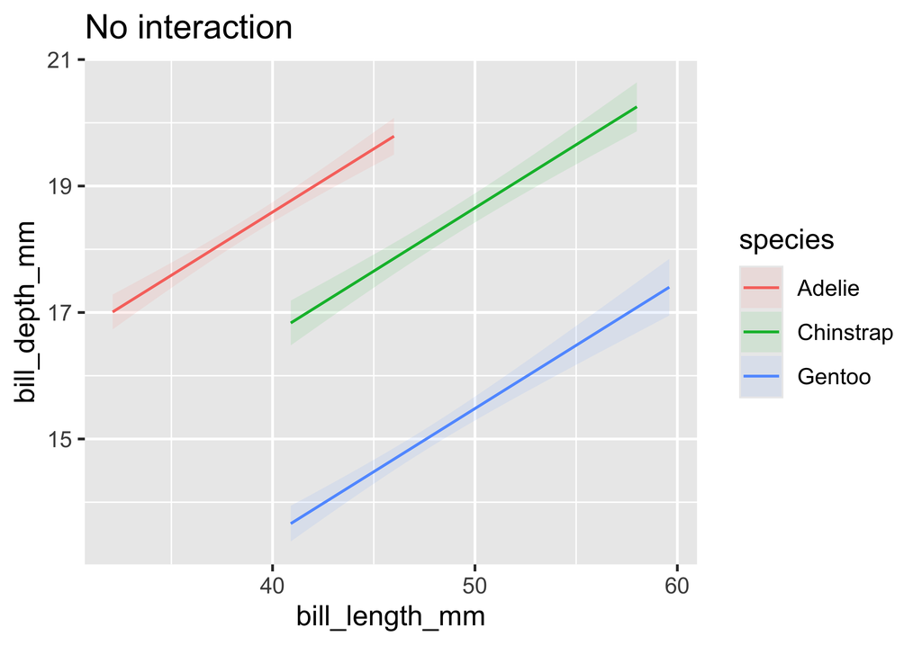

```r
bill_m1 |>
  plot_predictions(
    by = c("bill_length_mm", "species")) +
  labs(title = "No interaction")
```

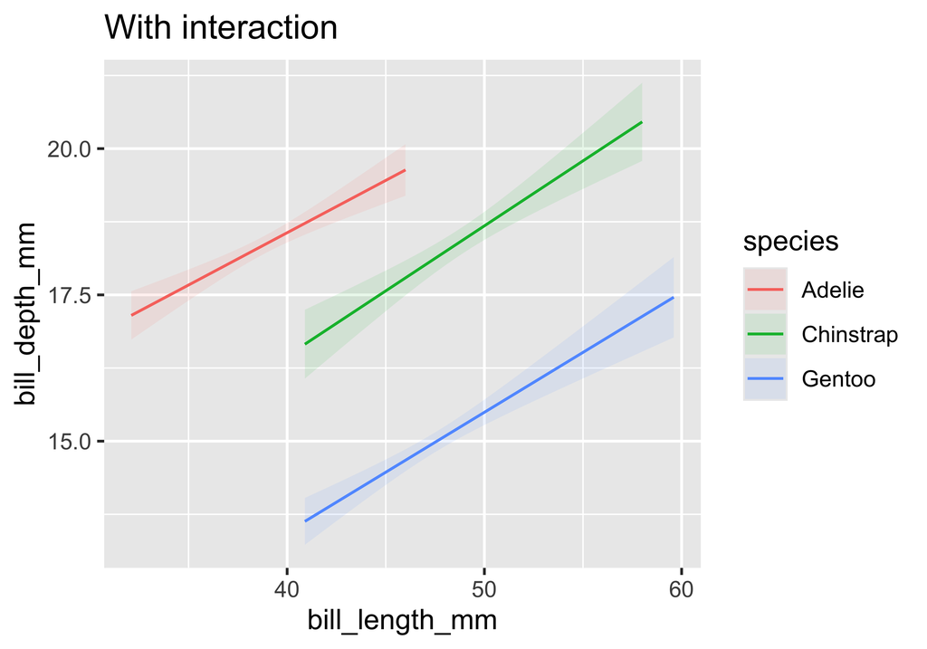

```r
bill_m4 |>
  plot_predictions(
    by = c("bill_length_mm", "species")) +
  labs(title = "With interaction")
```

## Continuous–factor

```r
scc <- read_csv("data/itve-milk-scc/milk-scc.csv") |>
  rename(
    cow_id = cowid,
    milk_yield_kg = kgmilk,
    somatic_cell_count = cellcount) |>
  mutate(
    breed = factor(
      breed,
      levels = c(1,2,3,8),
      labels = c("Red Danish", "Holstein", "Jersey", "Cross-breed")),
    parity = factor(parity)
  ) |>
  tidyr::drop_na()
```

## Continuous–factor

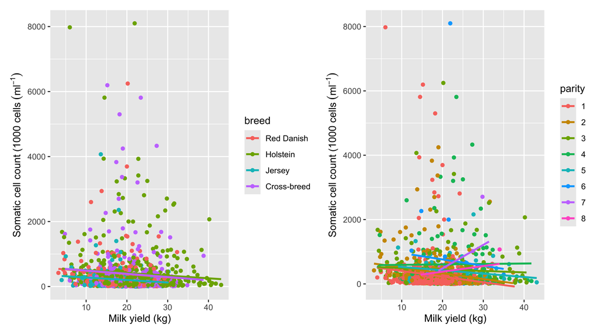

## Continuous–factor

```r
scc_m1 <- lm(somatic_cell_count ~ milk_yield_kg + parity, data = scc)
scc_m2 <- lm(somatic_cell_count ~ milk_yield_kg * parity, data = scc)
anova(scc_m2)
## Analysis of Variance Table
##
## Response: somatic_cell_count
##                        Df    Sum Sq Mean Sq F value    Pr(>F)
## milk_yield_kg           1   1368328 1368328  2.5764    0.1087
## parity                  7  21771120 3110160  5.8561 1.078e-06 ***
## milk_yield_kg:parity    7   3678319  525474  0.9894    0.4373
## Residuals            1123 596425913  531101
## ---
## Signif. codes:  0 '***' 0.001 '**' 0.01 '*' 0.05 '.' 0.1 ' ' 1
```

## Continuous–factor

```r
scc_m2 |>
 plot_predictions(by = c("milk_yield_kg", "parity")) +
 scc_labs
```

[figure not shown]

Maybe, but very uncertain effects

Also, the model is wrong, why?

## Continuous–continuous

In continuous–continuous interactions we don’t need to worry about coding

This type of interaction is represented by a new variable that is the product of the two variables

If we have $x_1$ and $x_2$, the interaction would be be $(x_1 \times x_2)$

```r
bill_cint1 <- lm(bill_depth_mm ~ bill_length_mm + flipper_length_mm, data = penguins)
bill_cint2 <- lm(bill_depth_mm ~ bill_length_mm * flipper_length_mm, data = penguins)
```

## Continuous–continuous

```r
bill_cint1 <- lm(bill_depth_mm ~ bill_length_mm + flipper_length_mm, data = penguins)
bill_cint2 <- lm(bill_depth_mm ~ bill_length_mm * flipper_length_mm, data = penguins)
```

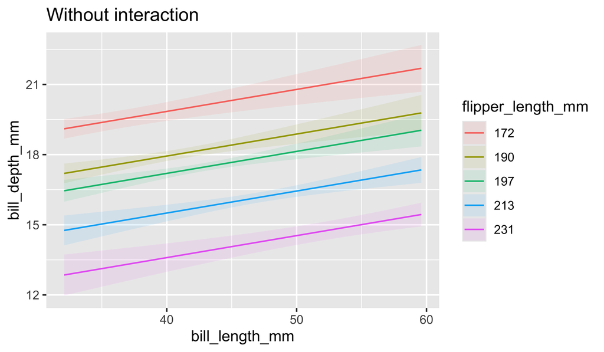

```r
bill_cint1 |>
  plot_predictions(
    condition = list("bill_length_mm",
      flipper_length_mm = "fivenum")) +
  labs(title = "Without interaction")
```

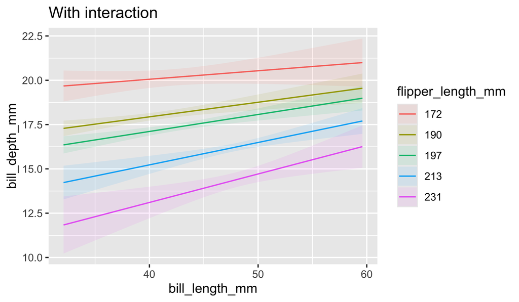

```r
bill_cint2 |>
  plot_predictions(
    condition = list("bill_length_mm",
      flipper_length_mm = "fivenum")) +
  labs(title = "With interaction")
```

## Continuous–continuous

Comparing the model without the interaction and the one with it

```r
anova(bill_cint1, bill_cint2)
## Analysis of Variance Table
##
## Model 1: bill_depth_mm ~ bill_length_mm + flipper_length_mm
## Model 2: bill_depth_mm ~ bill_length_mm * flipper_length_mm
##   Res.Df    RSS Df Sum of Sq      F Pr(>F)
## 1    339 825.32
## 2    338 820.06  1    5.2617 2.1687 0.1418
```

What this is testing is whether `Model 2` is statistically **different** to `Model 1`

Here we see that the result of the test is that we *fail to reject the null hypothesis that Model 1 and Model 2 are equivalent*

## Factor–factor

Factor–factor interactions estimate different effects of levels of factor $f_1$ for each level of factor $f_2$

This is where the names two-way ANOVA, three-way ANOVA come from — multiple factors in a model

# Pig weight example

## Pig weight gain

Pigs were feed different amounts (0 and 5mg) of two vitamins and average daily gain of individual pigs was recorded

```r
pig_gain <- read_excel("data/pig-daily-gain/pig-daily-gain.xlsx") |>
  janitor::clean_names() |>
  mutate(
    across(starts_with("vitamin"), .fns = factor)
  )
pig_gain
## # A tibble: 20 × 3
##     gain vitamin_1 vitamin_2
##    <dbl> <fct>     <fct>
##  1 0.585 0         0
##  2 0.536 0         0
##  3 0.458 0         0
##  4 0.486 0         0
##  5 0.536 0         0
##  6 0.567 0         5
##  7 0.545 0         5
##  8 0.589 0         5
##  9 0.536 0         5
## 10 0.549 0         5
## 11 0.473 5         0
## 12 0.45  5         0
## 13 0.869 5         0
## 14 0.473 5         0
## 15 0.464 5         0
## 16 0.684 5         5
## 17 0.702 5         5
## 18 0.9   5         5
## 19 0.698 5         5
## 20 0.693 5         5
```

## Pig weight gain

Models with main effects only

```r
gain_m1 <- lm(gain ~ vitamin_1 + vitamin_2, data = pig_gain)
```

and with main effects plus interaction

```r
gain_m2 <- lm(gain ~ vitamin_1 * vitamin_2, data = pig_gain)
```

## Pig weight gain?

```r
anova(gain_m1, gain_m2)
## Analysis of Variance Table
##
## Model 1: gain ~ vitamin_1 + vitamin_2
## Model 2: gain ~ vitamin_1 * vitamin_2
##   Res.Df     RSS Df Sum of Sq     F Pr(>F)
## 1     17 0.20559
## 2     16 0.17648  1  0.029108 2.639 0.1238
```

## Pig weight gain?

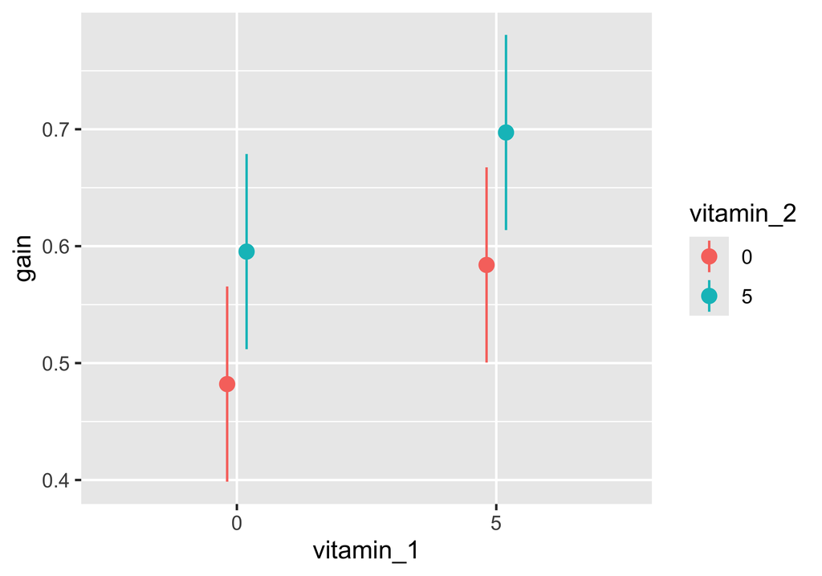

```r
gain_m1 |>
  plot_predictions(
    by = c("vitamin_1", "vitamin_2"))
```

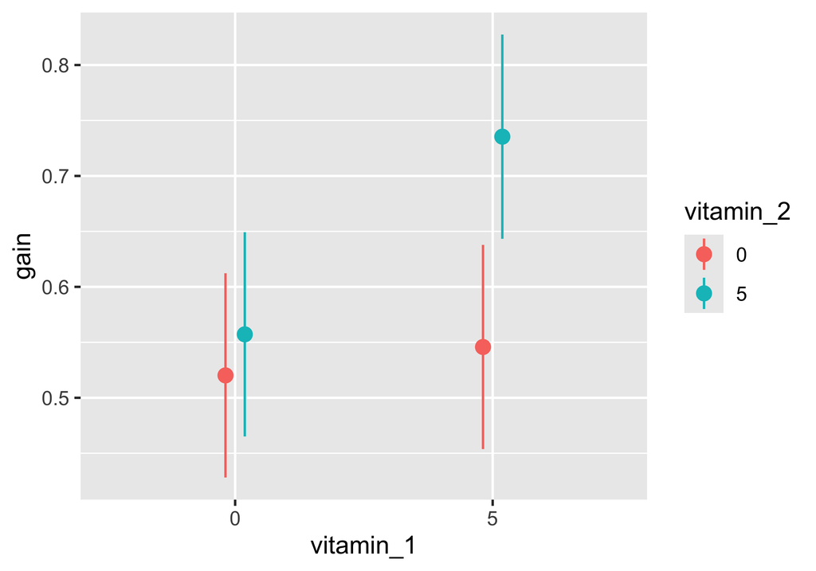

```r
gain_m2 |>
  plot_predictions(
    by = c("vitamin_1", "vitamin_2"))
```

Is there an effect?

## Pig weight gain

The combined effect is small overall but most visible when `vitamin_1` = 5mg

```r
gain_m2 |>
  avg_predictions(
    by = c("vitamin_1", "vitamin_2"),
    hypothesis = ~ sequential | vitamin_1)
##
##  vitamin_1 Hypothesis Estimate Std. Error     z Pr(>|z|)   S   2.5 % 97.5 %
##          0  (5) - (0)    0.037     0.0664 0.557  0.57751 0.8 -0.0932  0.167
##          5  (5) - (0)    0.190     0.0664 2.854  0.00431 7.9  0.0594  0.320
##
## Type:  response
```

## Pig weight gain

```r
gain_m2 |>
  avg_predictions(variables = c("vitamin_1", "vitamin_2"))
##
##  vitamin_1 vitamin_2 Estimate Std. Error    z Pr(>|z|)     S 2.5 % 97.5 %
##          0         0    0.520      0.047 11.1   <0.001  92.3 0.428  0.612
##          0         5    0.557      0.047 11.9   <0.001 105.4 0.465  0.649
##          5         0    0.546      0.047 11.6   <0.001 101.3 0.454  0.638
##          5         5    0.735      0.047 15.7   <0.001 181.1 0.643  0.827
##
## Type:  response
```

Expected average weight gain for each combination of `vitamin_1` and `vitamin_2`

Each row in the output has a name

- `b1` for row 1,
- `b2` for row 2, etc

## Pig weight gain

This allows you to specify any hypothesis test you want

For example; what is the difference in average weight gain between pigs given 0 and 5mg of `vitamin_2` when `vitamin_1` = 0mg?

```r
gain_m2 |>
  avg_predictions(
    variables = c("vitamin_1", "vitamin_2"),
    hypothesis = "b2 = b1") # test hypothesis of no diff!
##
##  Hypothesis Estimate Std. Error     z Pr(>|z|)   S   2.5 % 97.5 %
##       b2=b1    0.037     0.0664 0.557    0.578 0.8 -0.0932  0.167
##
## Type:  response
```

Fail to reject $\text{H}_0$

## Pig weight gain

This allows you to specify any hypothesis test you want

For example; what is the difference in average weight gain between pigs given 0 and 5mg of `vitamin_2` when `vitamin_1` = 5mg?

```r
gain_m2 |>
  avg_predictions(
    variables = c("vitamin_1", "vitamin_2"),
    hypothesis = "b4 = b3") # test hypothesis of no diff!
##
##  Hypothesis Estimate Std. Error    z Pr(>|z|)   S  2.5 % 97.5 %
##       b4=b3     0.19     0.0664 2.85  0.00431 7.9 0.0594   0.32
##
## Type:  response
```

Reject $\text{H}_0$ at 95% confidence level

## Pig weight gain

Or you can test all pairwise comparisons

```r
gain_m2 |>
  avg_predictions(
    variables = c("vitamin_1", "vitamin_2"),
    hypothesis = ~ pairwise) # test all pairwise comparisons
##
##     Hypothesis Estimate Std. Error      z Pr(>|z|)   S   2.5 % 97.5 %
##  (0 5) - (0 0)   0.0370     0.0664  0.557  0.57751 0.8 -0.0932  0.167
##  (5 0) - (0 0)   0.0256     0.0664  0.385  0.69994 0.5 -0.1046  0.156
##  (5 5) - (0 0)   0.2152     0.0664  3.240  0.00120 9.7  0.0850  0.345
##  (5 0) - (0 5)  -0.0114     0.0664 -0.172  0.86373 0.2 -0.1416  0.119
##  (5 5) - (0 5)   0.1782     0.0664  2.683  0.00730 7.1  0.0480  0.308
##  (5 5) - (5 0)   0.1896     0.0664  2.854  0.00431 7.9  0.0594  0.320
##
## Type:  response
```

## Pig weight gain

Or you can test a comparison of each other level to the reference level

```r
gain_m2 |>
  avg_predictions(
    variables = c("vitamin_1", "vitamin_2"),
    hypothesis = ~ reference) # test groups against 0,0 "control"
##
##     Hypothesis Estimate Std. Error     z Pr(>|z|)   S   2.5 % 97.5 %
##  (0 5) - (0 0)   0.0370     0.0664 0.557   0.5775 0.8 -0.0932  0.167
##  (5 0) - (0 0)   0.0256     0.0664 0.385   0.6999 0.5 -0.1046  0.156
##  (5 5) - (0 0)   0.2152     0.0664 3.240   0.0012 9.7  0.0850  0.345
##
## Type:  response
```